# Project 2

## Steps and tasks:

1. **Read the column description and ensure you understand each attribute well
1. I have read all columns well and know what each column means

   ID: This is the customer ID given to each customer. It is a unique number. Age: This is the Customer's age in years completed. Exp: This is the years of professional experience of a customer which will always be +ve. It means how much exp does a customer has. Zip: This is the home address ZIP code this can be same as many customer can live in same area. Income: Annual income of the customer means how much a customer earn a year. Family: This is family size of a customer. How much member does he/she has. CCAvg: This is the Avg. spending on credit cards per month which means how much money has been spend using c-card. Education: This is education column where it tells how much a customer is qualifed. Mortgage: this is mortgage column which means value of house mortgage . Per Loan: This is the target column which tells us did the customer accept the personal loan offered in the last campaig. Sec Acc: This column informs us that the customer have a securities account with the bank or not. CDAcc: This column tells us that the customer have a certificate of deposit (CD) account with the bank or not. Online: This column tells us that the customer used facilities such as internet banking facilities. C-Card: This column tells if the customer used a credit card issued by UniversalBan.
1. **Study the data distribution in each attribute, share your findings
1. I started with the **excel** ananlysis there I sorted the data according to 'ID' to check any missing data but no data is missing. Then I saw the range of each attributes ID: Unique number has 5000 unique value Age: 23 - 67 Exp: -3 - 43 According to me Exp cannot be in -ve so need to remove data with -ve Exp entries Zip: 9307 - 96651 Income: 8 - 224 Family: 1 - 4 CCAvg: 0 - 10 Education: 1 - 3 Mortgage: 0 - 635 Per Loan: 0 - 1 This is the target column Sec Acc,CDAcc,Online,C-Card: 0 - 1
1. **Get the target column distribution. Your comments
1. See In[23]
1. **Split the data into training and test set in the ratio of 70:30 respectively
1. I have splited the data in 70:30
1. **Use different classification models (Logistic, K-NN and Naïve Bayes) to predict the likelihood of a liability customer buying personal loans
1. various model such as KNN, LOG Reg and Naive bayes have been made
1. **Print the confusion matrix for all the above models
1. See In[175], In[178], In[181]
1. **Give your reasoning on which is the best model in this case and why it performs better
1. The best model is knn as it has accuracy of 96.59% in Iteration 3 F1 score : 0.8016 precision score : 0.8707 recall score : 0.7426 KNN is best because it is based on nearest neighbour. By seeing its nearest neighbour it predicts the value.

   Though it is little slow but this model(KNN) has the highes scores compared to other two after this log regression then Navie bayes.

**NOTE Models have different scores in iteration2 and iteration3, in itertion2 only Logistic Reg is better than iteration 3 and rest two are better in iteration3 than iteration 2. So after seeing all the factors and values I have consider iteration3 score and based on that I have answered

# **NOTES

Iteration 1 : In this I have considered all independent variable as this is the first iteration, I want to see what will be the accuracy if I consider all columns

Iteration 4 : In this I perform grid search and tune the model to get best possible values for hyperparmater so that my model will perfrom best

For every iteration till 3. I have created a new dataframe eg df1,df2,df3 for analysis..

# **Iteration 1

```python
import numpy as np
import pandas as pd
import seaborn as sns
import matplotlib.pyplot as plt

from sklearn.preprocessing import LabelEncoder, OneHotEncoder, StandardScaler
from sklearn.model_selection import train_test_split

from sklearn.model_selection import cross_val_predict, cross_val_score
from sklearn.model_selection import GridSearchCV

from sklearn.metrics import confusion_matrix,classification_report,accuracy_score,precision_score,recall_score,f1_score
from sklearn import metrics
from matplotlib.colors import ListedColormap

from sklearn.linear_model import LogisticRegression
from sklearn.naive_bayes import GaussianNB
from sklearn.neighbors import KNeighborsClassifier
from sklearn.svm import SVC


sns.set_style('whitegrid')
%matplotlib inline
```

```python
df=pd.read_csv('Bank_Personal_Loan_Modelling-1.csv')
```

```python
df=df.drop(labels='ID',axis=1)
df.head()
```

|  | Age | Experience | Income | ZIP Code | Family | CCAvg | Education | Mortgage | Personal Loan | Securities Account | CD Account | Online | CreditCard |
| --- | --- | --- | --- | --- | --- | --- | --- | --- | --- | --- | --- | --- | --- |
| 0 | 25 | 1 | 49 | 91107 | 4 | 1.60 | 1 | 0 | 0 | 1 | 0 | 0 | 0 |
| 1 | 45 | 19 | 34 | 90089 | 3 | 1.50 | 1 | 0 | 0 | 1 | 0 | 0 | 0 |
| 2 | 39 | 15 | 11 | 94720 | 1 | 1.00 | 1 | 0 | 0 | 0 | 0 | 0 | 0 |
| 3 | 35 | 9 | 100 | 94112 | 1 | 2.70 | 2 | 0 | 0 | 0 | 0 | 0 | 0 |
| 4 | 35 | 8 | 45 | 91330 | 4 | 1.00 | 2 | 0 | 0 | 0 | 0 | 0 | 1 |

```python
df.shape
```

```
(5000, 13)
```

```python
df.info()
```

```
<class 'pandas.core.frame.DataFrame'>
RangeIndex: 5000 entries, 0 to 4999
Data columns (total 13 columns):
Age                   5000 non-null int64
Experience            5000 non-null int64
Income                5000 non-null int64
ZIP Code              5000 non-null int64
Family                5000 non-null int64
CCAvg                 5000 non-null float64
Education             5000 non-null int64
Mortgage              5000 non-null int64
Personal Loan         5000 non-null int64
Securities Account    5000 non-null int64
CD Account            5000 non-null int64
Online                5000 non-null int64
CreditCard            5000 non-null int64
dtypes: float64(1), int64(12)
memory usage: 507.9 KB
```

```python
df.describe().transpose()
```

|  | count | mean | std | min | 25% | 50% | 75% | max |
| --- | --- | --- | --- | --- | --- | --- | --- | --- |
| Age | 5,000.00 | 45.34 | 11.46 | 23.00 | 35.00 | 45.00 | 55.00 | 67.00 |
| Experience | 5,000.00 | 20.10 | 11.47 | -3.00 | 10.00 | 20.00 | 30.00 | 43.00 |
| Income | 5,000.00 | 73.77 | 46.03 | 8.00 | 39.00 | 64.00 | 98.00 | 224.00 |
| ZIP Code | 5,000.00 | 93,152.50 | 2,121.85 | 9,307.00 | 91,911.00 | 93,437.00 | 94,608.00 | 96,651.00 |
| Family | 5,000.00 | 2.40 | 1.15 | 1.00 | 1.00 | 2.00 | 3.00 | 4.00 |
| CCAvg | 5,000.00 | 1.94 | 1.75 | 0.00 | 0.70 | 1.50 | 2.50 | 10.00 |
| Education | 5,000.00 | 1.88 | 0.84 | 1.00 | 1.00 | 2.00 | 3.00 | 3.00 |
| Mortgage | 5,000.00 | 56.50 | 101.71 | 0.00 | 0.00 | 0.00 | 101.00 | 635.00 |
| Personal Loan | 5,000.00 | 0.10 | 0.29 | 0.00 | 0.00 | 0.00 | 0.00 | 1.00 |
| Securities Account | 5,000.00 | 0.10 | 0.31 | 0.00 | 0.00 | 0.00 | 0.00 | 1.00 |
| CD Account | 5,000.00 | 0.06 | 0.24 | 0.00 | 0.00 | 0.00 | 0.00 | 1.00 |
| Online | 5,000.00 | 0.60 | 0.49 | 0.00 | 0.00 | 1.00 | 1.00 | 1.00 |
| CreditCard | 5,000.00 | 0.29 | 0.46 | 0.00 | 0.00 | 0.00 | 1.00 | 1.00 |

```python
#converting categ data to seperate columns
df['Education'] = df['Education'].replace({1: 'Undergrad', 2: 'Graduate', 3: 'Advanced/Professional'})
```

```python
df = pd.get_dummies(df, columns=['Education'])
```

```python
df.head()
```

|  | Age | Experience | Income | ZIP Code | Family | CCAvg | Mortgage | Personal Loan | Securities Account | CD Account | Online | CreditCard | Education_Advanced/Professional | Education_Graduate | Education_Undergrad |
| --- | --- | --- | --- | --- | --- | --- | --- | --- | --- | --- | --- | --- | --- | --- | --- |
| 0 | 25 | 1 | 49 | 91107 | 4 | 1.60 | 0 | 0 | 1 | 0 | 0 | 0 | 0 | 0 | 1 |
| 1 | 45 | 19 | 34 | 90089 | 3 | 1.50 | 0 | 0 | 1 | 0 | 0 | 0 | 0 | 0 | 1 |
| 2 | 39 | 15 | 11 | 94720 | 1 | 1.00 | 0 | 0 | 0 | 0 | 0 | 0 | 0 | 0 | 1 |
| 3 | 35 | 9 | 100 | 94112 | 1 | 2.70 | 0 | 0 | 0 | 0 | 0 | 0 | 0 | 1 | 0 |
| 4 | 35 | 8 | 45 | 91330 | 4 | 1.00 | 0 | 0 | 0 | 0 | 0 | 1 | 0 | 1 | 0 |

```python
#checking if they are not unique value. after getting output they are not
df['ZIP Code'].unique()
```

```
array([91107, 90089, 94720, 94112, 91330, 92121, 91711, 93943, 93023,
       94710, 90277, 93106, 94920, 91741, 95054, 95010, 94305, 91604,
       94015, 90095, 91320, 95521, 95064, 90064, 94539, 94104, 94117,
       94801, 94035, 92647, 95814, 94114, 94115, 92672, 94122, 90019,
       95616, 94065, 95014, 91380, 95747, 92373, 92093, 94005, 90245,
       95819, 94022, 90404, 93407, 94523, 90024, 91360, 95670, 95123,
       90045, 91335, 93907, 92007, 94606, 94611, 94901, 92220, 93305,
       95134, 94612, 92507, 91730, 94501, 94303, 94105, 94550, 92612,
       95617, 92374, 94080, 94608, 93555, 93311, 94704, 92717, 92037,
       95136, 94542, 94143, 91775, 92703, 92354, 92024, 92831, 92833,
       94304, 90057, 92130, 91301, 92096, 92646, 92182, 92131, 93720,
       90840, 95035, 93010, 94928, 95831, 91770, 90007, 94102, 91423,
       93955, 94107, 92834, 93117, 94551, 94596, 94025, 94545, 95053,
       90036, 91125, 95120, 94706, 95827, 90503, 90250, 95817, 95503,
       93111, 94132, 95818, 91942, 90401, 93524, 95133, 92173, 94043,
```

[output cut: 38 more lines]

```
Text(0.5,1,'Exp')
```

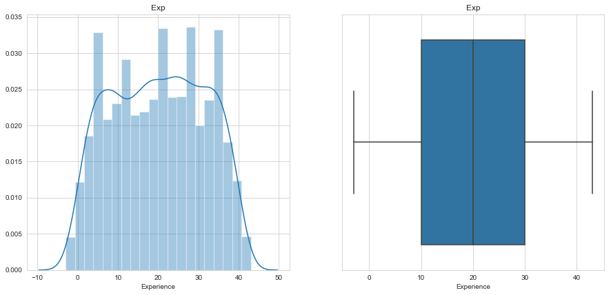

```python
#checking outliers for Experience column
plt.figure(figsize=(15,15))

plt.subplot(2,2,1)
sns.distplot(df['Experience'])
plt.title('Exp')

plt.subplot(2,2,2)
sns.boxplot(df["Experience"])
plt.title('Exp')


#Note= It starts from -3. as Exp cnnot be in -ve
```

```
Text(0.5,1,'Mortgage')
```

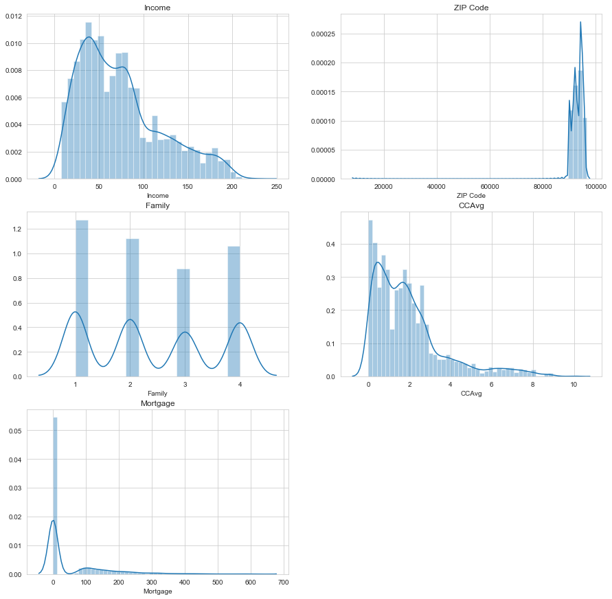

```python
#checking columns for outliers
plt.figure(figsize=(15,15))

plt.subplot(3,2,1)
sns.distplot(df['Income'])
plt.title('Income')

plt.subplot(3,2,2)
sns.distplot(df['ZIP Code'])
plt.title('ZIP Code')

plt.subplot(3,2,3)
sns.distplot(df['Family'])
plt.title('Family')

plt.subplot(3,2,4)
sns.distplot(df['CCAvg'])
plt.title('CCAvg')

plt.subplot(3,2,5)
sns.distplot(df['Mortgage'])
plt.title('Mortgage')
```

```
Personal Loan
0    4520
1     480
dtype: int64
This target column can suffer curse of dimensionlity as very few case of 1 i.e acceptance of loan. the data is highly skewed. There are more people who rejected this loan thus stratergies that were applied before were failed
```

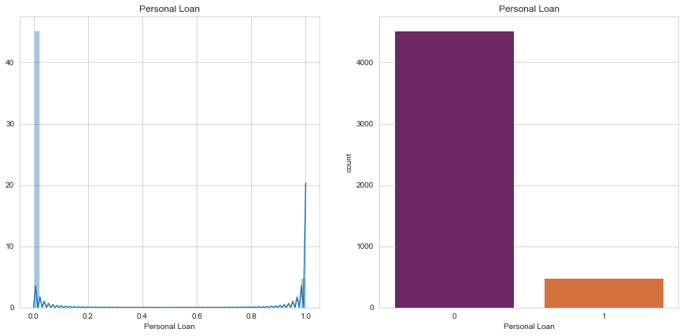

```python
#plotting and seeing target column
plt.figure(figsize=(15,15))

plt.subplot(2,2,1)
sns.distplot(df['Personal Loan'])
plt.title('Personal Loan')

plt.subplot(2,2,2)
sns.countplot('Personal Loan',data=df,palette='inferno')
plt.title('Personal Loan')

print(df.groupby('Personal Loan').size())


print("This target column can suffer curse of dimensionlity as very few case of 1 i.e acceptance of loan. the data is highly skewed. There are more people who rejected this loan thus stratergies that were applied before were failed")
```

```python
df.groupby('Personal Loan').count()
```

| Personal Loan | Age | Experience | Income | ZIP Code | Family | CCAvg | Mortgage | Securities Account | CD Account | Online | CreditCard | Education_Advanced/Professional | Education_Graduate | Education_Undergrad |
| --- | --- | --- | --- | --- | --- | --- | --- | --- | --- | --- | --- | --- | --- | --- |
| 0 | 4520 | 4520 | 4520 | 4520 | 4520 | 4520 | 4520 | 4520 | 4520 | 4520 | 4520 | 4520 | 4520 | 4520 |
| 1 | 480 | 480 | 480 | 480 | 480 | 480 | 480 | 480 | 480 | 480 | 480 | 480 | 480 | 480 |

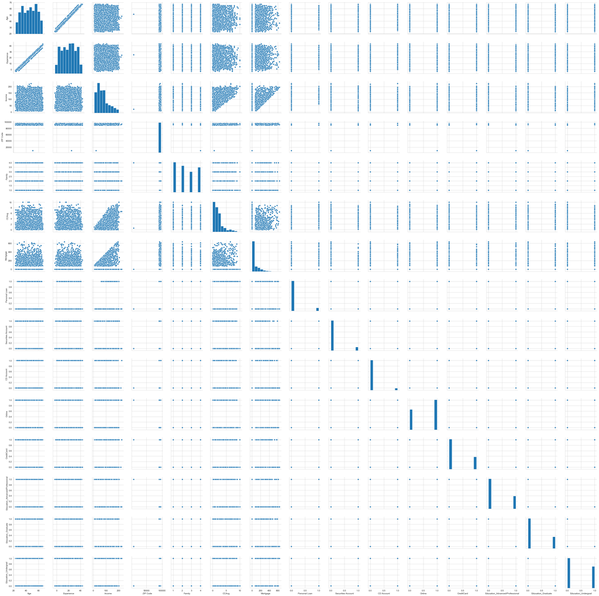

```python
sns.pairplot(df)
```

```python
pd.options.display.float_format = '{:,.2f}'.format
corr=df.corr()
corr[corr<0.2]=0
corr
```

|  | Age | Experience | Income | ZIP Code | Family | CCAvg | Mortgage | Personal Loan | Securities Account | CD Account | Online | CreditCard | Education_Advanced/Professional | Education_Graduate | Education_Undergrad |
| --- | --- | --- | --- | --- | --- | --- | --- | --- | --- | --- | --- | --- | --- | --- | --- |
| Age | 1.00 | 0.99 | 0.00 | 0.00 | 0.00 | 0.00 | 0.00 | 0.00 | 0.00 | 0.00 | 0.00 | 0.00 | 0.00 | 0.00 | 0.00 |
| Experience | 0.99 | 1.00 | 0.00 | 0.00 | 0.00 | 0.00 | 0.00 | 0.00 | 0.00 | 0.00 | 0.00 | 0.00 | 0.00 | 0.00 | 0.00 |
| Income | 0.00 | 0.00 | 1.00 | 0.00 | 0.00 | 0.65 | 0.21 | 0.50 | 0.00 | 0.00 | 0.00 | 0.00 | 0.00 | 0.00 | 0.22 |
| ZIP Code | 0.00 | 0.00 | 0.00 | 1.00 | 0.00 | 0.00 | 0.00 | 0.00 | 0.00 | 0.00 | 0.00 | 0.00 | 0.00 | 0.00 | 0.00 |
| Family | 0.00 | 0.00 | 0.00 | 0.00 | 1.00 | 0.00 | 0.00 | 0.00 | 0.00 | 0.00 | 0.00 | 0.00 | 0.00 | 0.00 | 0.00 |
| CCAvg | 0.00 | 0.00 | 0.65 | 0.00 | 0.00 | 1.00 | 0.00 | 0.37 | 0.00 | 0.00 | 0.00 | 0.00 | 0.00 | 0.00 | 0.00 |
| Mortgage | 0.00 | 0.00 | 0.21 | 0.00 | 0.00 | 0.00 | 1.00 | 0.00 | 0.00 | 0.00 | 0.00 | 0.00 | 0.00 | 0.00 | 0.00 |
| Personal Loan | 0.00 | 0.00 | 0.50 | 0.00 | 0.00 | 0.37 | 0.00 | 1.00 | 0.00 | 0.32 | 0.00 | 0.00 | 0.00 | 0.00 | 0.00 |
| Securities Account | 0.00 | 0.00 | 0.00 | 0.00 | 0.00 | 0.00 | 0.00 | 0.00 | 1.00 | 0.32 | 0.00 | 0.00 | 0.00 | 0.00 | 0.00 |
| CD Account | 0.00 | 0.00 | 0.00 | 0.00 | 0.00 | 0.00 | 0.00 | 0.32 | 0.32 | 1.00 | 0.00 | 0.28 | 0.00 | 0.00 | 0.00 |
| Online | 0.00 | 0.00 | 0.00 | 0.00 | 0.00 | 0.00 | 0.00 | 0.00 | 0.00 | 0.00 | 1.00 | 0.00 | 0.00 | 0.00 | 0.00 |
| CreditCard | 0.00 | 0.00 | 0.00 | 0.00 | 0.00 | 0.00 | 0.00 | 0.00 | 0.00 | 0.28 | 0.00 | 1.00 | 0.00 | 0.00 | 0.00 |
| Education_Advanced/Professional | 0.00 | 0.00 | 0.00 | 0.00 | 0.00 | 0.00 | 0.00 | 0.00 | 0.00 | 0.00 | 0.00 | 0.00 | 1.00 | 0.00 | 0.00 |
| Education_Graduate | 0.00 | 0.00 | 0.00 | 0.00 | 0.00 | 0.00 | 0.00 | 0.00 | 0.00 | 0.00 | 0.00 | 0.00 | 0.00 | 1.00 | 0.00 |
| Education_Undergrad | 0.00 | 0.00 | 0.22 | 0.00 | 0.00 | 0.00 | 0.00 | 0.00 | 0.00 | 0.00 | 0.00 | 0.00 | 0.00 | 0.00 | 1.00 |

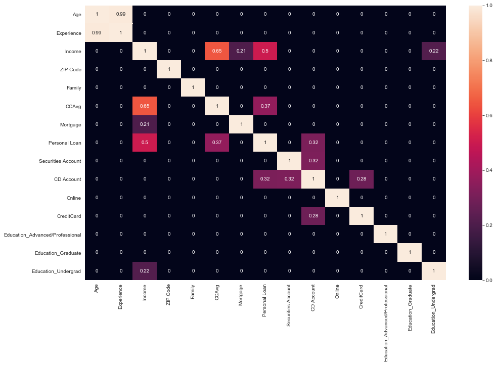

```python
plt.figure(figsize=(16,10))
sns.heatmap(corr, annot=True)
plt.show()
```

```python
df.var()
```

```
Age                                     131.40
Experience                              131.51
Income                                2,119.10
ZIP Code                          4,502,256.75
Family                                    1.32
CCAvg                                     3.05
Mortgage                             10,345.70
Personal Loan                             0.09
Securities Account                        0.09
CD Account                                0.06
Online                                    0.24
CreditCard                                0.21
Education_Advanced/Professional           0.21
Education_Graduate                        0.20
Education_Undergrad                       0.24
dtype: float64
```

```python
#Getting X and y
X,y=df.drop(labels='Personal Loan',axis=1).values,df[['Personal Loan']].values
```

```python
df[df.isnull().any(axis=1)]
```

|  | Age | Experience | Income | ZIP Code | Family | CCAvg | Mortgage | Personal Loan | Securities Account | CD Account | Online | CreditCard | Education_Advanced/Professional | Education_Graduate | Education_Undergrad |
| --- | --- | --- | --- | --- | --- | --- | --- | --- | --- | --- | --- | --- | --- | --- | --- |

```python
#splitting X and y in tarin and test
X_train, X_test, y_train, y_test= train_test_split(X, y, test_size=0.3, random_state=0)
```

```python
scale=StandardScaler()
X_train=scale.fit_transform(X_train)
X_test=scale.transform(X_test)
```

```python
#Logistic Reg
log_reg=LogisticRegression(random_state=0)
log_reg.fit(X_train,y_train)

y_pred=log_reg.predict(X_test)

confusion_matrix(y_test,y_pred)
```

```
array([[1353,   19],
       [  42,   86]], dtype=int64)
```

```python
print("score for train : {0:.4f}".format(log_reg.score(X_train,y_train)))
print("score for test : {0:.4f}".format(log_reg.score(X_test,y_test)))
print("accuracy : {0:.4f}".format(accuracy_score(y_test,y_pred)))
```

```
score for train : 0.9600
score for test : 0.9593
accuracy : 0.9593
```

```python
print("F1 score : {0:.4f}".format(f1_score(y_test,y_pred)))
print("precision score : {0:.4f}".format(precision_score(y_test,y_pred)))
print("recall score : {0:.4f}".format(recall_score(y_test,y_pred)))
```

```
F1 score : 0.7382
precision score : 0.8190
recall score : 0.6719
```

```python
print(metrics.classification_report(y_test,y_pred))
```

```
             precision    recall  f1-score   support

          0       0.97      0.99      0.98      1372
          1       0.82      0.67      0.74       128

avg / total       0.96      0.96      0.96      1500
```

```python
#Naive bayes
nv_bayes=GaussianNB()
nv_bayes.fit(X_train,y_train)

y_pred=nv_bayes.predict(X_test)

confusion_matrix(y_test,y_pred)
```

```
array([[1272,  100],
       [  52,   76]], dtype=int64)
```

```python
print("score for train : {0:.4f}".format(nv_bayes.score(X_train,y_train)))
print("score for test : {0:.4f}".format(nv_bayes.score(X_test,y_test)))
print("accuracy : {0:.4f}".format(accuracy_score(y_test,y_pred)))
```

```
score for train : 0.8946
score for test : 0.8987
accuracy : 0.8987
```

```python
print("F1 score : {0:.4f}".format(f1_score(y_test,y_pred)))
print("precision score : {0:.4f}".format(precision_score(y_test,y_pred)))
print("recall score : {0:.4f}".format(recall_score(y_test,y_pred)))
```

```
F1 score : 0.5000
precision score : 0.4318
recall score : 0.5938
```

```python
print(metrics.classification_report(y_test,y_pred))
```

```
             precision    recall  f1-score   support

          0       0.96      0.93      0.94      1372
          1       0.43      0.59      0.50       128

avg / total       0.92      0.90      0.91      1500
```

```python
#KNN
knn=KNeighborsClassifier(n_neighbors = 9 , metric='minkowski', p=2) #this is for eucledian only not for minkowski
knn.fit(X_train,y_train)

y_pred=knn.predict(X_test)


confusion_matrix(y_test,y_pred)
```

```
array([[1369,    3],
       [  59,   69]], dtype=int64)
```

```python
print("score for train : {0:.4f}".format(knn.score(X_train,y_train)))
print("score for test : {0:.4f}".format(knn.score(X_test,y_test)))
print("accuracy : {0:.4f}".format(accuracy_score(y_test,y_pred)))
```

```
score for train : 0.9569
score for test : 0.9587
accuracy : 0.9587
```

```python
print("F1 score : {0:.4f}".format(f1_score(y_test,y_pred)))
print("precision score : {0:.4f}".format(precision_score(y_test,y_pred)))
print("recall score : {0:.4f}".format(recall_score(y_test,y_pred)))
```

```
F1 score : 0.6900
precision score : 0.9583
recall score : 0.5391
```

```python
print(metrics.classification_report(y_test,y_pred))
```

```
             precision    recall  f1-score   support

          0       0.96      1.00      0.98      1372
          1       0.96      0.54      0.69       128

avg / total       0.96      0.96      0.95      1500
```

# **Iteration 2

```python
df2=df
```

```python
df2.head()
```

|  | Age | Experience | Income | ZIP Code | Family | CCAvg | Mortgage | Personal Loan | Securities Account | CD Account | Online | CreditCard | Education_Advanced/Professional | Education_Graduate | Education_Undergrad |
| --- | --- | --- | --- | --- | --- | --- | --- | --- | --- | --- | --- | --- | --- | --- | --- |
| 0 | 25 | 1 | 49 | 91107 | 4 | 1.60 | 0 | 0 | 1 | 0 | 0 | 0 | 0 | 0 | 1 |
| 1 | 45 | 19 | 34 | 90089 | 3 | 1.50 | 0 | 0 | 1 | 0 | 0 | 0 | 0 | 0 | 1 |
| 2 | 39 | 15 | 11 | 94720 | 1 | 1.00 | 0 | 0 | 0 | 0 | 0 | 0 | 0 | 0 | 1 |
| 3 | 35 | 9 | 100 | 94112 | 1 | 2.70 | 0 | 0 | 0 | 0 | 0 | 0 | 0 | 1 | 0 |
| 4 | 35 | 8 | 45 | 91330 | 4 | 1.00 | 0 | 0 | 0 | 0 | 0 | 1 | 0 | 1 | 0 |

```python
df2=df2[df2['Experience']>0]
#df2.iloc[85:316]
df2.shape
```

```
(4882, 15)
```

```python
df2['Experience'].min()
```

```
1
```

```python
X2,y2=df2.drop(labels='Personal Loan',axis=1).values,df2[['Personal Loan']].values
```

```python
#splitting X and y in tarin and test
X_train2, X_test2, y_train2, y_test2 = train_test_split(X2, y2, test_size=0.3, random_state=0)
```

```python
scale=StandardScaler()
X_train2=scale.fit_transform(X_train2)
X_test2=scale.transform(X_test2)
```

```python
#Logistic Reg
log_reg=LogisticRegression(random_state=0)
log_reg.fit(X_train2,y_train2)

y_pred2=log_reg.predict(X_test2)


confusion_matrix(y_test2,y_pred2)
```

```
array([[1317,   12],
       [  47,   89]], dtype=int64)
```

```python
print(log_reg.score(X_train2,y_train2))
print(log_reg.score(X_test2,y_test2))
```

```
0.9587357330992098
0.9597269624573379
```

```python
print("accuracy : {0:.4f}".format(accuracy_score(y_test2,y_pred2)))
print("F1 score : {0:.4f}".format(f1_score(y_test2,y_pred2)))
print("precision score : {0:.4f}".format(precision_score(y_test2,y_pred2)))
print("recall score : {0:.4f}".format(recall_score(y_test2,y_pred2)))
print(metrics.classification_report(y_test2,y_pred2))
```

```
accuracy : 0.9597
F1 score : 0.7511
precision score : 0.8812
recall score : 0.6544
             precision    recall  f1-score   support

          0       0.97      0.99      0.98      1329
          1       0.88      0.65      0.75       136

avg / total       0.96      0.96      0.96      1465
```

```python
#Naive bayes
nv_bayes=GaussianNB()
nv_bayes.fit(X_train2,y_train2)

y_pred2=nv_bayes.predict(X_test2)



confusion_matrix(y_test2,y_pred2)
```

```
array([[1224,  105],
       [  43,   93]], dtype=int64)
```

```python
print(nv_bayes.score(X_train2,y_train2))
print(nv_bayes.score(X_test2,y_test2))
```

```
0.8923031899326895
0.898976109215017
```

```python
print("accuracy : {0:.4f}".format(accuracy_score(y_test2,y_pred2)))
print("F1 score : {0:.4f}".format(f1_score(y_test2,y_pred2)))
print("precision score : {0:.4f}".format(precision_score(y_test2,y_pred2)))
print("recall score : {0:.4f}".format(recall_score(y_test2,y_pred2)))
print(metrics.classification_report(y_test2,y_pred2))
```

```
accuracy : 0.8990
F1 score : 0.5569
precision score : 0.4697
recall score : 0.6838
             precision    recall  f1-score   support

          0       0.97      0.92      0.94      1329
          1       0.47      0.68      0.56       136

avg / total       0.92      0.90      0.91      1465
```

```python
#KNN
knn=KNeighborsClassifier(n_neighbors = 5, metric='minkowski', p=2) #this is for eucledian only not for minkowski
knn.fit(X_train2,y_train2)

y_pred2=knn.predict(X_test2)


confusion_matrix(y_test2,y_pred2)
```

```
array([[1326,    3],
       [  63,   73]], dtype=int64)
```

```python
print(knn.score(X_train2,y_train2))
print(knn.score(X_test2,y_test2))
```

```
0.9651741293532339
0.9549488054607509
```

```python
print("accuracy : {0:.4f}".format(accuracy_score(y_test2,y_pred2)))
print("F1 score : {0:.4f}".format(f1_score(y_test2,y_pred2)))
print("precision score : {0:.4f}".format(precision_score(y_test2,y_pred2)))
print("recall score : {0:.4f}".format(recall_score(y_test2,y_pred2)))
print(metrics.classification_report(y_test2,y_pred2))
```

```
accuracy : 0.9549
F1 score : 0.6887
precision score : 0.9605
recall score : 0.5368
             precision    recall  f1-score   support

          0       0.95      1.00      0.98      1329
          1       0.96      0.54      0.69       136

avg / total       0.96      0.95      0.95      1465
```

# **ITERATION 3

```python
df3=df2[['Income','CCAvg','CD Account','Education_Advanced/Professional','Education_Graduate','Education_Undergrad','Personal Loan']]
df3.head()
df2['Experience'].min()
```

```
1
```

```python
X3,y3=df3.drop(labels='Personal Loan',axis=1).values,df3[['Personal Loan']].values
```

```python
#splitting X and y in tarin and test
X_train3, X_test3, y_train3, y_test3 = train_test_split(X3, y3, test_size=0.3, random_state=0)
```

```python
scale=StandardScaler()
X_train3=scale.fit_transform(X_train3)
X_test3=scale.transform(X_test3)
```

```python
#Logistic Reg
log_reg=LogisticRegression(random_state=0)
log_reg.fit(X_train3,y_train3)

y_pred3=log_reg.predict(X_test3)


confusion_matrix(y_test3,y_pred3)
```

```
array([[1317,   12],
       [  52,   84]], dtype=int64)
```

```python
print(log_reg.score(X_train3,y_train3))
print(log_reg.score(X_test3,y_test3))
```

```
0.9569798068481123
0.9563139931740614
```

```python
print("accuracy : {0:.4f}".format(accuracy_score(y_test3,y_pred3)))
print("F1 score : {0:.4f}".format(f1_score(y_test3,y_pred3)))
print("precision score : {0:.4f}".format(precision_score(y_test3,y_pred3)))
print("recall score : {0:.4f}".format(recall_score(y_test3,y_pred3)))
print(metrics.classification_report(y_test3,y_pred3))
```

```
accuracy : 0.9563
F1 score : 0.7241
precision score : 0.8750
recall score : 0.6176
             precision    recall  f1-score   support

          0       0.96      0.99      0.98      1329
          1       0.88      0.62      0.72       136

avg / total       0.95      0.96      0.95      1465
```

```python
#Naive bayes
nv_bayes=GaussianNB()
nv_bayes.fit(X_train3,y_train3)

y_pred3=nv_bayes.predict(X_test3)



confusion_matrix(y_test3,y_pred3)
```

```
array([[1240,   89],
       [  50,   86]], dtype=int64)
```

```python
print(nv_bayes.score(X_train3,y_train3))
print(nv_bayes.score(X_test3,y_test3))
```

```
0.8978636230611647
0.9051194539249147
```

```python
print("accuracy : {0:.4f}".format(accuracy_score(y_test3,y_pred3)))
print("F1 score : {0:.4f}".format(f1_score(y_test3,y_pred3)))
print("precision score : {0:.4f}".format(precision_score(y_test3,y_pred3)))
print("recall score : {0:.4f}".format(recall_score(y_test3,y_pred3)))
print(metrics.classification_report(y_test3,y_pred3))
```

```
accuracy : 0.9051
F1 score : 0.5531
precision score : 0.4914
recall score : 0.6324
             precision    recall  f1-score   support

          0       0.96      0.93      0.95      1329
          1       0.49      0.63      0.55       136

avg / total       0.92      0.91      0.91      1465
```

```python
#KNN
knn=KNeighborsClassifier(n_neighbors = 5, metric='minkowski', p=2) #this is for eucledian only not for minkowski
knn.fit(X_train3,y_train3)

y_pred3=knn.predict(X_test3)


confusion_matrix(y_test3,y_pred3)
```

```
array([[1314,   15],
       [  35,  101]], dtype=int64)
```

```python
print(knn.score(X_train3,y_train3))
print(knn.score(X_test3,y_test3))
```

```
0.9780509218612818
0.9658703071672355
```

```python
print("accuracy : {0:.4f}".format(accuracy_score(y_test3,y_pred3)))
print("F1 score : {0:.4f}".format(f1_score(y_test3,y_pred3)))
print("precision score : {0:.4f}".format(precision_score(y_test3,y_pred3)))
print("recall score : {0:.4f}".format(recall_score(y_test3,y_pred3)))
print(metrics.classification_report(y_test3,y_pred3))
```

```
accuracy : 0.9659
F1 score : 0.8016
precision score : 0.8707
recall score : 0.7426
             precision    recall  f1-score   support

          0       0.97      0.99      0.98      1329
          1       0.87      0.74      0.80       136

avg / total       0.96      0.97      0.96      1465
```

# iteration 4 : tuning parameter

```python
knn.get_params()
```

```
{'algorithm': 'auto',
 'leaf_size': 30,
 'metric': 'minkowski',
 'metric_params': None,
 'n_jobs': 1,
 'n_neighbors': 5,
 'p': 2,
 'weights': 'uniform'}
```

```python
params = {'n_neighbors': range(1,50,2)}
```

```python
grid_search_cv = GridSearchCV(KNeighborsClassifier(),
                              params,
                              n_jobs=-1,
                              verbose=1)
```

```python
grid_search_cv.fit(X_train3, y_train3)
```

```
Fitting 3 folds for each of 25 candidates, totalling 75 fits
```

```
[Parallel(n_jobs=-1)]: Done  26 tasks      | elapsed:    6.4s
[Parallel(n_jobs=-1)]: Done  75 out of  75 | elapsed:    8.3s finished
```

```
GridSearchCV(cv=None, error_score='raise',
       estimator=KNeighborsClassifier(algorithm='auto', leaf_size=30, metric='minkowski',
           metric_params=None, n_jobs=1, n_neighbors=5, p=2,
           weights='uniform'),
       fit_params=None, iid=True, n_jobs=-1,
       param_grid={'n_neighbors': range(1, 50, 2)},
       pre_dispatch='2*n_jobs', refit=True, return_train_score='warn',
       scoring=None, verbose=1)
```

```python
grid_search_cv.best_estimator_
```

```
KNeighborsClassifier(algorithm='auto', leaf_size=30, metric='minkowski',
           metric_params=None, n_jobs=1, n_neighbors=5, p=2,
           weights='uniform')
```

```python
grid_search_cv.best_params_
```

```
{'n_neighbors': 5}
```

```python
grid_search_cv.cv_results_
```

[output not shown]

[output cut: 50 more lines]

[output not shown]

# **DOUBLE CHECK

```python
# creating odd list of K for KNN
myList = list(range(1,50))

# subsetting just the odd ones

neighbors = list(filter(lambda x: x % 2 != 0, myList))
```

```python
# empty list that will hold accuracy scores
ac_scores = []

# perform accuracy metrics for values from 1,3,5....19
for k in neighbors:
    knn = KNeighborsClassifier(n_neighbors=k)
    knn.fit(X_train, y_train)
    # predict the response
    y_pred = knn.predict(X_test)
    # evaluate accuracy
    scores = accuracy_score(y_test, y_pred)
    ac_scores.append(scores)

# changing to misclassification error
MSE = [1 - x for x in ac_scores]

# determining best k
optimal_k = neighbors[MSE.index(min(MSE))]
print("The optimal number of neighbors is %d" % optimal_k)
```

[output not shown]

```
The optimal number of neighbors is 5
```

```python
#KNN
knn=KNeighborsClassifier(algorithm='auto', leaf_size=30, metric='minkowski',
           metric_params=None, n_jobs=1, n_neighbors=5, p=2,
           weights='uniform')
#knn=KNeighborsClassifier(n_neighbors = 5, metric='minkowski', p=2) #this is for eucledian only not for minkowski
knn.fit(X_train3,y_train3)

y_pred3=knn.predict(X_test3)


confusion_matrix(y_test3,y_pred3)
```

```
array([[1314,   15],
       [  35,  101]], dtype=int64)
```

```python
print(knn.score(X_train3,y_train3))
print(knn.score(X_test3,y_test3))
print("accuracy : {0:.4f}".format(accuracy_score(y_test3,y_pred3)))
print("F1 score : {0:.4f}".format(f1_score(y_test3,y_pred3)))
print("precision score : {0:.4f}".format(precision_score(y_test3,y_pred3)))
print("recall score : {0:.4f}".format(recall_score(y_test3,y_pred3)))
print(metrics.classification_report(y_test3,y_pred3))
```

```
0.9780509218612818
0.9658703071672355
accuracy : 0.9659
F1 score : 0.8016
precision score : 0.8707
recall score : 0.7426
             precision    recall  f1-score   support

          0       0.97      0.99      0.98      1329
          1       0.87      0.74      0.80       136

avg / total       0.96      0.97      0.96      1465
```